# Risk Factor Analysis

## Outcome Variable

**Outcome Variable:** whz

## Predictor Variables

**Intervention Variable:** predfeed3

**Adjustment Set:**

- arm
- sex
- month
- brthmon
- W_mage
- meducyrs
- feducyrs
- hhwealth_quart
- hfoodsec
- W_mhtcm
- W_mwtkg
- W_mbmi
- vagbrth
- W_gagebrth
- W_birthwt
- W_birthlen
- W_nrooms
- W_nchldlt5
- W_parity
- impfloor
- impsan
- safeh20
- delta_W_mage
- delta_meducyrs
- delta_feducyrs
- delta_hhwealth_quart
- delta_hfoodsec
- delta_W_mhtcm
- delta_W_mwtkg
- delta_W_mbmi
- delta_vagbrth
- delta_W_gagebrth
- delta_W_birthwt
- delta_W_birthlen
- delta_W_nrooms
- delta_W_nchldlt5
- delta_W_parity
- delta_impfloor
- delta_impsan
- delta_safeh20

## Stratifying Variables

The analysis was stratified on these variable(s):

- agecat
- studyid
- country

## Data Summary

| agecat | studyid | country | predfeed3 | n_cell | n | outcome_variable |
| --- | --- | --- | --- | --- | --- | --- |
| Birth | EE | PAKISTAN | 1 | 22 | 22 | whz |
| Birth | EE | PAKISTAN | 0 | 0 | 22 | whz |
| Birth | GMS-Nepal | NEPAL | 1 | 352 | 422 | whz |
| Birth | GMS-Nepal | NEPAL | 0 | 70 | 422 | whz |
| Birth | JiVitA-3 | BANGLADESH | 1 | 9638 | 10634 | whz |
| Birth | JiVitA-3 | BANGLADESH | 0 | 996 | 10634 | whz |
| Birth | JiVitA-4 | BANGLADESH | 1 | 89 | 97 | whz |
| Birth | JiVitA-4 | BANGLADESH | 0 | 8 | 97 | whz |
| Birth | MAL-ED | BANGLADESH | 1 | 164 | 202 | whz |
| Birth | MAL-ED | BANGLADESH | 0 | 38 | 202 | whz |
| Birth | MAL-ED | BRAZIL | 1 | 23 | 55 | whz |
| Birth | MAL-ED | BRAZIL | 0 | 32 | 55 | whz |
| Birth | MAL-ED | INDIA | 1 | 27 | 39 | whz |
| Birth | MAL-ED | INDIA | 0 | 12 | 39 | whz |
| Birth | MAL-ED | NEPAL | 1 | 14 | 25 | whz |
| Birth | MAL-ED | NEPAL | 0 | 11 | 25 | whz |
| Birth | MAL-ED | PERU | 1 | 145 | 218 | whz |
| Birth | MAL-ED | PERU | 0 | 73 | 218 | whz |
| Birth | MAL-ED | SOUTH AFRICA | 1 | 33 | 99 | whz |
| Birth | MAL-ED | SOUTH AFRICA | 0 | 66 | 99 | whz |
| Birth | MAL-ED | TANZANIA, UNITED REPUBLIC OF | 1 | 24 | 95 | whz |
| Birth | MAL-ED | TANZANIA, UNITED REPUBLIC OF | 0 | 71 | 95 | whz |
| 6 months | EE | PAKISTAN | 1 | 39 | 39 | whz |
| 6 months | EE | PAKISTAN | 0 | 0 | 39 | whz |
| 6 months | GMS-Nepal | NEPAL | 1 | 367 | 441 | whz |
| 6 months | GMS-Nepal | NEPAL | 0 | 74 | 441 | whz |
| 6 months | JiVitA-3 | BANGLADESH | 1 | 8500 | 9310 | whz |
| 6 months | JiVitA-3 | BANGLADESH | 0 | 810 | 9310 | whz |
| 6 months | JiVitA-4 | BANGLADESH | 1 | 76 | 88 | whz |
| 6 months | JiVitA-4 | BANGLADESH | 0 | 12 | 88 | whz |
| 6 months | MAL-ED | BANGLADESH | 1 | 191 | 233 | whz |
| 6 months | MAL-ED | BANGLADESH | 0 | 42 | 233 | whz |
| 6 months | MAL-ED | BRAZIL | 1 | 93 | 187 | whz |
| 6 months | MAL-ED | BRAZIL | 0 | 94 | 187 | whz |
| 6 months | MAL-ED | INDIA | 1 | 147 | 210 | whz |
| 6 months | MAL-ED | INDIA | 0 | 63 | 210 | whz |
| 6 months | MAL-ED | NEPAL | 1 | 113 | 227 | whz |
| 6 months | MAL-ED | NEPAL | 0 | 114 | 227 | whz |
| 6 months | MAL-ED | PERU | 1 | 176 | 270 | whz |
| 6 months | MAL-ED | PERU | 0 | 94 | 270 | whz |
| 6 months | MAL-ED | SOUTH AFRICA | 1 | 63 | 244 | whz |
| 6 months | MAL-ED | SOUTH AFRICA | 0 | 181 | 244 | whz |
| 6 months | MAL-ED | TANZANIA, UNITED REPUBLIC OF | 1 | 64 | 212 | whz |
| 6 months | MAL-ED | TANZANIA, UNITED REPUBLIC OF | 0 | 148 | 212 | whz |
| 24 months | EE | PAKISTAN | 1 | 20 | 20 | whz |
| 24 months | EE | PAKISTAN | 0 | 0 | 20 | whz |
| 24 months | GMS-Nepal | NEPAL | 1 | 322 | 384 | whz |
| 24 months | GMS-Nepal | NEPAL | 0 | 62 | 384 | whz |
| 24 months | JiVitA-3 | BANGLADESH | 1 | 4417 | 4833 | whz |
| 24 months | JiVitA-3 | BANGLADESH | 0 | 416 | 4833 | whz |
| 24 months | JiVitA-4 | BANGLADESH | 1 | 135 | 150 | whz |
| 24 months | JiVitA-4 | BANGLADESH | 0 | 15 | 150 | whz |
| 24 months | MAL-ED | BANGLADESH | 1 | 168 | 205 | whz |
| 24 months | MAL-ED | BANGLADESH | 0 | 37 | 205 | whz |
| 24 months | MAL-ED | BRAZIL | 1 | 79 | 152 | whz |
| 24 months | MAL-ED | BRAZIL | 0 | 73 | 152 | whz |
| 24 months | MAL-ED | INDIA | 1 | 139 | 202 | whz |
| 24 months | MAL-ED | INDIA | 0 | 63 | 202 | whz |
| 24 months | MAL-ED | NEPAL | 1 | 110 | 220 | whz |
| 24 months | MAL-ED | NEPAL | 0 | 110 | 220 | whz |
| 24 months | MAL-ED | PERU | 1 | 131 | 198 | whz |
| 24 months | MAL-ED | PERU | 0 | 67 | 198 | whz |
| 24 months | MAL-ED | SOUTH AFRICA | 1 | 60 | 228 | whz |
| 24 months | MAL-ED | SOUTH AFRICA | 0 | 168 | 228 | whz |
| 24 months | MAL-ED | TANZANIA, UNITED REPUBLIC OF | 1 | 54 | 184 | whz |
| 24 months | MAL-ED | TANZANIA, UNITED REPUBLIC OF | 0 | 130 | 184 | whz |

The following strata were considered:

- agecat: 24 months, studyid: EE, country: PAKISTAN
- agecat: 24 months, studyid: GMS-Nepal, country: NEPAL
- agecat: 24 months, studyid: JiVitA-3, country: BANGLADESH
- agecat: 24 months, studyid: JiVitA-4, country: BANGLADESH
- agecat: 24 months, studyid: MAL-ED, country: BANGLADESH
- agecat: 24 months, studyid: MAL-ED, country: BRAZIL
- agecat: 24 months, studyid: MAL-ED, country: INDIA
- agecat: 24 months, studyid: MAL-ED, country: NEPAL
- agecat: 24 months, studyid: MAL-ED, country: PERU
- agecat: 24 months, studyid: MAL-ED, country: SOUTH AFRICA
- agecat: 24 months, studyid: MAL-ED, country: TANZANIA, UNITED REPUBLIC OF
- agecat: 6 months, studyid: EE, country: PAKISTAN
- agecat: 6 months, studyid: GMS-Nepal, country: NEPAL
- agecat: 6 months, studyid: JiVitA-3, country: BANGLADESH
- agecat: 6 months, studyid: JiVitA-4, country: BANGLADESH
- agecat: 6 months, studyid: MAL-ED, country: BANGLADESH
- agecat: 6 months, studyid: MAL-ED, country: BRAZIL
- agecat: 6 months, studyid: MAL-ED, country: INDIA
- agecat: 6 months, studyid: MAL-ED, country: NEPAL
- agecat: 6 months, studyid: MAL-ED, country: PERU
- agecat: 6 months, studyid: MAL-ED, country: SOUTH AFRICA
- agecat: 6 months, studyid: MAL-ED, country: TANZANIA, UNITED REPUBLIC OF
- agecat: Birth, studyid: EE, country: PAKISTAN
- agecat: Birth, studyid: GMS-Nepal, country: NEPAL
- agecat: Birth, studyid: JiVitA-3, country: BANGLADESH
- agecat: Birth, studyid: JiVitA-4, country: BANGLADESH
- agecat: Birth, studyid: MAL-ED, country: BANGLADESH
- agecat: Birth, studyid: MAL-ED, country: BRAZIL
- agecat: Birth, studyid: MAL-ED, country: INDIA
- agecat: Birth, studyid: MAL-ED, country: NEPAL
- agecat: Birth, studyid: MAL-ED, country: PERU
- agecat: Birth, studyid: MAL-ED, country: SOUTH AFRICA
- agecat: Birth, studyid: MAL-ED, country: TANZANIA, UNITED REPUBLIC OF

### Dropped Strata

- agecat: Birth, studyid: EE, country: PAKISTAN
- agecat: 6 months, studyid: EE, country: PAKISTAN
- agecat: 24 months, studyid: EE, country: PAKISTAN

## Methods Detail

We’re interested in the causal parameters $E[Y_a]$ for all values of $a \in \mathcal{A}$. These parameters represent the mean outcome if, possibly contrary to fact, we intervened to set all units to have $A=a$. Under the randomization and positivity assumptions, these are identified by the statistical parameters $\psi_a=E_W[E_{Y|A,W}(Y|A=a,W)]$. In addition, we’re interested in the mean of $Y$, $E[Y]$ under no intervention (the observed mean). We will estimate these parameters by using SuperLearner to fit the relevant likelihood factors – $E_{Y|A,W}(Y|A=a,W)$ and $p(A=a|W)$, and then updating our likelihood fit using a joint TMLE.

For unadjusted analyses ($W=\{\}$), initial likelihoods were estimated using Lrnr_glm to estimate the simple $E(Y|A)$ and Lrnr_mean to estimate $p(A)$. For adjusted analyses, a small library containing Lrnr_glmnet, Lrnr_xgboost, and Lrnr_mean was used.

Having estimated these parameters, we will then use the delta method to estimate relative risks and attributable risks relative to a prespecified baseline level of $A$.

# Results Detail

## Results Plots

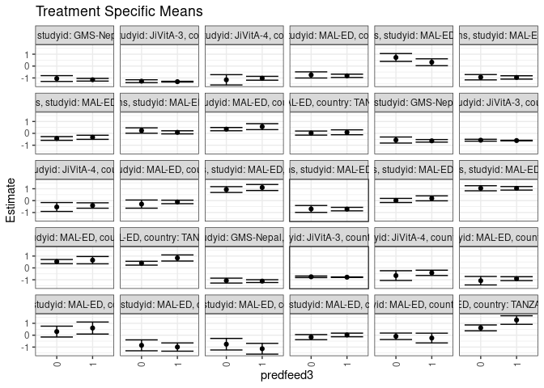

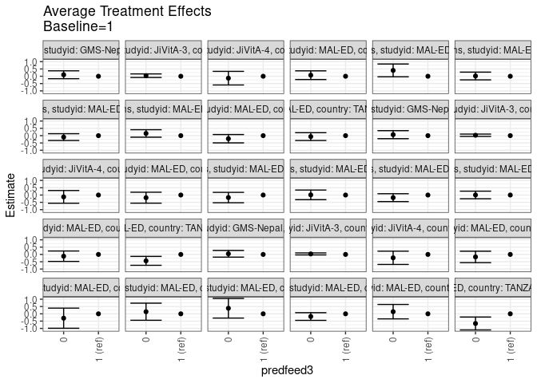

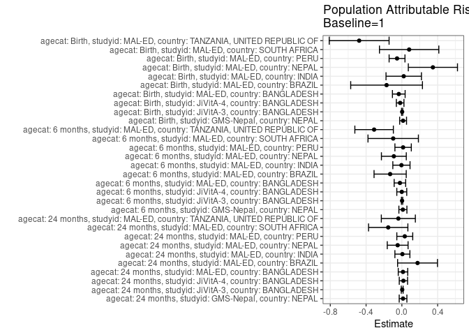

## Results Table

### Parameter: TSM

| agecat | studyid | country | intervention_level | baseline_level | estimate | ci_lower | ci_upper |
| --- | --- | --- | --- | --- | --- | --- | --- |
| Birth | GMS-Nepal | NEPAL | 1 | NA | -1.1129777 | -1.2319132 | -0.9940422 |
| Birth | GMS-Nepal | NEPAL | 0 | NA | -1.0690108 | -1.2767898 | -0.8612318 |
| Birth | JiVitA-3 | BANGLADESH | 1 | NA | -0.7830301 | -0.8062632 | -0.7597970 |
| Birth | JiVitA-3 | BANGLADESH | 0 | NA | -0.7485629 | -0.8144357 | -0.6826901 |
| Birth | JiVitA-4 | BANGLADESH | 1 | NA | -0.4156180 | -0.6383645 | -0.1928714 |
| Birth | JiVitA-4 | BANGLADESH | 0 | NA | -0.6475000 | -1.0569566 | -0.2380434 |
| Birth | MAL-ED | BANGLADESH | 1 | NA | -0.9066977 | -1.0711866 | -0.7422088 |
| Birth | MAL-ED | BANGLADESH | 0 | NA | -1.0772529 | -1.4336488 | -0.7208570 |
| Birth | MAL-ED | BRAZIL | 1 | NA | 0.6025874 | 0.0944321 | 1.1107426 |
| Birth | MAL-ED | BRAZIL | 0 | NA | 0.3029582 | -0.1549762 | 0.7608925 |
| Birth | MAL-ED | INDIA | 1 | NA | -0.9988493 | -1.3475148 | -0.6501839 |
| Birth | MAL-ED | INDIA | 0 | NA | -0.8546007 | -1.3132105 | -0.3959909 |
| Birth | MAL-ED | NEPAL | 1 | NA | -1.1413779 | -1.5956790 | -0.6870767 |
| Birth | MAL-ED | NEPAL | 0 | NA | -0.7599400 | -1.2473832 | -0.2724967 |
| Birth | MAL-ED | PERU | 1 | NA | 0.0203488 | -0.1311876 | 0.1718852 |
| Birth | MAL-ED | PERU | 0 | NA | -0.1643487 | -0.3782327 | 0.0495353 |
| Birth | MAL-ED | SOUTH AFRICA | 1 | NA | -0.2402753 | -0.6512075 | 0.1706569 |
| Birth | MAL-ED | SOUTH AFRICA | 0 | NA | -0.0939508 | -0.3663372 | 0.1784355 |
| Birth | MAL-ED | TANZANIA, UNITED REPUBLIC OF | 1 | NA | 1.2771951 | 0.9155918 | 1.6387984 |
| Birth | MAL-ED | TANZANIA, UNITED REPUBLIC OF | 0 | NA | 0.6149274 | 0.3678259 | 0.8620289 |
| 6 months | GMS-Nepal | NEPAL | 1 | NA | -0.6314120 | -0.7413144 | -0.5215097 |
| 6 months | GMS-Nepal | NEPAL | 0 | NA | -0.5637039 | -0.8175397 | -0.3098681 |
| 6 months | JiVitA-3 | BANGLADESH | 1 | NA | -0.6064780 | -0.6320279 | -0.5809281 |
| 6 months | JiVitA-3 | BANGLADESH | 0 | NA | -0.5789100 | -0.6569611 | -0.5008589 |
| 6 months | JiVitA-4 | BANGLADESH | 1 | NA | -0.4099733 | -0.6367484 | -0.1831983 |
| 6 months | JiVitA-4 | BANGLADESH | 0 | NA | -0.5354296 | -0.9100483 | -0.1608110 |
| 6 months | MAL-ED | BANGLADESH | 1 | NA | -0.1087566 | -0.2554227 | 0.0379094 |
| 6 months | MAL-ED | BANGLADESH | 0 | NA | -0.2918162 | -0.6359719 | 0.0523395 |
| 6 months | MAL-ED | BRAZIL | 1 | NA | 1.1064791 | 0.8540231 | 1.3589351 |
| 6 months | MAL-ED | BRAZIL | 0 | NA | 0.9342627 | 0.6887020 | 1.1798235 |
| 6 months | MAL-ED | INDIA | 1 | NA | -0.7137140 | -0.8617261 | -0.5657019 |
| 6 months | MAL-ED | INDIA | 0 | NA | -0.7022566 | -0.9928307 | -0.4116824 |
| 6 months | MAL-ED | NEPAL | 1 | NA | 0.1937174 | -0.0145069 | 0.4019416 |
| 6 months | MAL-ED | NEPAL | 0 | NA | 0.0142766 | -0.1587127 | 0.1872659 |
| 6 months | MAL-ED | PERU | 1 | NA | 1.0374895 | 0.8886506 | 1.1863283 |
| 6 months | MAL-ED | PERU | 0 | NA | 1.0424904 | 0.8283143 | 1.2566665 |
| 6 months | MAL-ED | SOUTH AFRICA | 1 | NA | 0.6533184 | 0.3457810 | 0.9608558 |
| 6 months | MAL-ED | SOUTH AFRICA | 0 | NA | 0.5311505 | 0.3551512 | 0.7071497 |
| 6 months | MAL-ED | TANZANIA, UNITED REPUBLIC OF | 1 | NA | 0.8360689 | 0.5788407 | 1.0932971 |
| 6 months | MAL-ED | TANZANIA, UNITED REPUBLIC OF | 0 | NA | 0.3958542 | 0.2344175 | 0.5572909 |
| 24 months | GMS-Nepal | NEPAL | 1 | NA | -1.1528961 | -1.2657737 | -1.0400184 |
| 24 months | GMS-Nepal | NEPAL | 0 | NA | -1.0508592 | -1.2954953 | -0.8062232 |
| 24 months | JiVitA-3 | BANGLADESH | 1 | NA | -1.3147283 | -1.3466386 | -1.2828180 |
| 24 months | JiVitA-3 | BANGLADESH | 0 | NA | -1.2754908 | -1.3945957 | -1.1563858 |
| 24 months | JiVitA-4 | BANGLADESH | 1 | NA | -1.0269559 | -1.1896285 | -0.8642834 |
| 24 months | JiVitA-4 | BANGLADESH | 0 | NA | -1.1581894 | -1.5919108 | -0.7244679 |
| 24 months | MAL-ED | BANGLADESH | 1 | NA | -0.8203016 | -0.9600185 | -0.6805848 |
| 24 months | MAL-ED | BANGLADESH | 0 | NA | -0.7471522 | -1.0065627 | -0.4877417 |
| 24 months | MAL-ED | BRAZIL | 1 | NA | 0.3228179 | 0.0351557 | 0.6104800 |
| 24 months | MAL-ED | BRAZIL | 0 | NA | 0.7245946 | 0.3945942 | 1.0545951 |
| 24 months | MAL-ED | INDIA | 1 | NA | -0.9576461 | -1.0983443 | -0.8169479 |
| 24 months | MAL-ED | INDIA | 0 | NA | -0.9396738 | -1.1639445 | -0.7154032 |
| 24 months | MAL-ED | NEPAL | 1 | NA | -0.3320815 | -0.5060605 | -0.1581024 |
| 24 months | MAL-ED | NEPAL | 0 | NA | -0.4315239 | -0.5878231 | -0.2752248 |
| 24 months | MAL-ED | PERU | 1 | NA | 0.0850820 | -0.0464541 | 0.2166182 |
| 24 months | MAL-ED | PERU | 0 | NA | 0.2359357 | 0.0099292 | 0.4619422 |
| 24 months | MAL-ED | SOUTH AFRICA | 1 | NA | 0.5647008 | 0.3135676 | 0.8158341 |
| 24 months | MAL-ED | SOUTH AFRICA | 0 | NA | 0.3558141 | 0.2183358 | 0.4932924 |
| 24 months | MAL-ED | TANZANIA, UNITED REPUBLIC OF | 1 | NA | 0.0889665 | -0.1165084 | 0.2944414 |
| 24 months | MAL-ED | TANZANIA, UNITED REPUBLIC OF | 0 | NA | 0.0241136 | -0.1480091 | 0.1962362 |

### Parameter: E(Y)

| agecat | studyid | country | intervention_level | baseline_level | estimate | ci_lower | ci_upper |
| --- | --- | --- | --- | --- | --- | --- | --- |
| Birth | GMS-Nepal | NEPAL | NA | NA | -1.0991706 | -1.2073693 | -0.9909719 |
| Birth | JiVitA-3 | BANGLADESH | NA | NA | -0.7798636 | -0.8022140 | -0.7575133 |
| Birth | JiVitA-4 | BANGLADESH | NA | NA | -0.4347423 | -0.6441144 | -0.2253701 |
| Birth | MAL-ED | BANGLADESH | NA | NA | -0.9411386 | -1.0895370 | -0.7927402 |
| Birth | MAL-ED | BRAZIL | NA | NA | 0.4316364 | 0.0969688 | 0.7663039 |
| Birth | MAL-ED | INDIA | NA | NA | -0.9779487 | -1.2664810 | -0.6894164 |
| Birth | MAL-ED | NEPAL | NA | NA | -0.7944000 | -1.1625222 | -0.4262778 |
| Birth | MAL-ED | PERU | NA | NA | -0.0335321 | -0.1564905 | 0.0894263 |
| Birth | MAL-ED | SOUTH AFRICA | NA | NA | -0.1588889 | -0.3845288 | 0.0667510 |
| Birth | MAL-ED | TANZANIA, UNITED REPUBLIC OF | NA | NA | 0.7996842 | 0.5874808 | 1.0118876 |
| 6 months | GMS-Nepal | NEPAL | NA | NA | -0.6198791 | -0.7206518 | -0.5191063 |
| 6 months | JiVitA-3 | BANGLADESH | NA | NA | -0.6040977 | -0.6286619 | -0.5795335 |
| 6 months | JiVitA-4 | BANGLADESH | NA | NA | -0.4110227 | -0.6122701 | -0.2097753 |
| 6 months | MAL-ED | BANGLADESH | NA | NA | -0.1304936 | -0.2625419 | 0.0015547 |
| 6 months | MAL-ED | BRAZIL | NA | NA | 0.9754144 | 0.7990651 | 1.1517638 |
| 6 months | MAL-ED | INDIA | NA | NA | -0.7185992 | -0.8491469 | -0.5880515 |
| 6 months | MAL-ED | NEPAL | NA | NA | 0.1041483 | -0.0311352 | 0.2394318 |
| 6 months | MAL-ED | PERU | NA | NA | 1.0514136 | 0.9289176 | 1.1739096 |
| 6 months | MAL-ED | SOUTH AFRICA | NA | NA | 0.5564071 | 0.4055220 | 0.7072922 |
| 6 months | MAL-ED | TANZANIA, UNITED REPUBLIC OF | NA | NA | 0.5257626 | 0.3871543 | 0.6643709 |
| 24 months | GMS-Nepal | NEPAL | NA | NA | -1.1396441 | -1.2416403 | -1.0376479 |
| 24 months | JiVitA-3 | BANGLADESH | NA | NA | -1.3109518 | -1.3423299 | -1.2795737 |
| 24 months | JiVitA-4 | BANGLADESH | NA | NA | -1.0096000 | -1.1619164 | -0.8572836 |
| 24 months | MAL-ED | BANGLADESH | NA | NA | -0.8076829 | -0.9296166 | -0.6857493 |
| 24 months | MAL-ED | BRAZIL | NA | NA | 0.4981140 | 0.2760418 | 0.7201863 |
| 24 months | MAL-ED | INDIA | NA | NA | -0.9516832 | -1.0703961 | -0.8329703 |
| 24 months | MAL-ED | NEPAL | NA | NA | -0.3790455 | -0.4958857 | -0.2622052 |
| 24 months | MAL-ED | PERU | NA | NA | 0.1176052 | -0.0015211 | 0.2367315 |
| 24 months | MAL-ED | SOUTH AFRICA | NA | NA | 0.4120797 | 0.2900939 | 0.5340654 |
| 24 months | MAL-ED | TANZANIA, UNITED REPUBLIC OF | NA | NA | 0.0495743 | -0.0857535 | 0.1849021 |

### Parameter: ATE

| agecat | studyid | country | intervention_level | baseline_level | estimate | ci_lower | ci_upper |
| --- | --- | --- | --- | --- | --- | --- | --- |
| Birth | GMS-Nepal | NEPAL | 1 | 1 | 0.0000000 | 0.0000000 | 0.0000000 |
| Birth | GMS-Nepal | NEPAL | 0 | 1 | 0.0439669 | -0.1848661 | 0.2727999 |
| Birth | JiVitA-3 | BANGLADESH | 1 | 1 | 0.0000000 | 0.0000000 | 0.0000000 |
| Birth | JiVitA-3 | BANGLADESH | 0 | 1 | 0.0344672 | -0.0337801 | 0.1027145 |
| Birth | JiVitA-4 | BANGLADESH | 1 | 1 | 0.0000000 | 0.0000000 | 0.0000000 |
| Birth | JiVitA-4 | BANGLADESH | 0 | 1 | -0.2318820 | -0.6871466 | 0.2233826 |
| Birth | MAL-ED | BANGLADESH | 1 | 1 | 0.0000000 | 0.0000000 | 0.0000000 |
| Birth | MAL-ED | BANGLADESH | 0 | 1 | -0.1705552 | -0.5640342 | 0.2229238 |
| Birth | MAL-ED | BRAZIL | 1 | 1 | 0.0000000 | 0.0000000 | 0.0000000 |
| Birth | MAL-ED | BRAZIL | 0 | 1 | -0.2996292 | -0.9893496 | 0.3900912 |
| Birth | MAL-ED | INDIA | 1 | 1 | 0.0000000 | 0.0000000 | 0.0000000 |
| Birth | MAL-ED | INDIA | 0 | 1 | 0.1442486 | -0.4414622 | 0.7299595 |
| Birth | MAL-ED | NEPAL | 1 | 1 | 0.0000000 | 0.0000000 | 0.0000000 |
| Birth | MAL-ED | NEPAL | 0 | 1 | 0.3814379 | -0.2914120 | 1.0542878 |
| Birth | MAL-ED | PERU | 1 | 1 | 0.0000000 | 0.0000000 | 0.0000000 |
| Birth | MAL-ED | PERU | 0 | 1 | -0.1846975 | -0.4477508 | 0.0783558 |
| Birth | MAL-ED | SOUTH AFRICA | 1 | 1 | 0.0000000 | 0.0000000 | 0.0000000 |
| Birth | MAL-ED | SOUTH AFRICA | 0 | 1 | 0.1463245 | -0.3472904 | 0.6399393 |
| Birth | MAL-ED | TANZANIA, UNITED REPUBLIC OF | 1 | 1 | 0.0000000 | 0.0000000 | 0.0000000 |
| Birth | MAL-ED | TANZANIA, UNITED REPUBLIC OF | 0 | 1 | -0.6622677 | -1.1035752 | -0.2209602 |
| 6 months | GMS-Nepal | NEPAL | 1 | 1 | 0.0000000 | 0.0000000 | 0.0000000 |
| 6 months | GMS-Nepal | NEPAL | 0 | 1 | 0.0677082 | -0.2073587 | 0.3427750 |
| 6 months | JiVitA-3 | BANGLADESH | 1 | 1 | 0.0000000 | 0.0000000 | 0.0000000 |
| 6 months | JiVitA-3 | BANGLADESH | 0 | 1 | 0.0275680 | -0.0535223 | 0.1086582 |
| 6 months | JiVitA-4 | BANGLADESH | 1 | 1 | 0.0000000 | 0.0000000 | 0.0000000 |
| 6 months | JiVitA-4 | BANGLADESH | 0 | 1 | -0.1254563 | -0.5613163 | 0.3104038 |
| 6 months | MAL-ED | BANGLADESH | 1 | 1 | 0.0000000 | 0.0000000 | 0.0000000 |
| 6 months | MAL-ED | BANGLADESH | 0 | 1 | -0.1830596 | -0.5581319 | 0.1920127 |
| 6 months | MAL-ED | BRAZIL | 1 | 1 | 0.0000000 | 0.0000000 | 0.0000000 |
| 6 months | MAL-ED | BRAZIL | 0 | 1 | -0.1722163 | -0.5276444 | 0.1832117 |
| 6 months | MAL-ED | INDIA | 1 | 1 | 0.0000000 | 0.0000000 | 0.0000000 |
| 6 months | MAL-ED | INDIA | 0 | 1 | 0.0114575 | -0.3186029 | 0.3415178 |
| 6 months | MAL-ED | NEPAL | 1 | 1 | 0.0000000 | 0.0000000 | 0.0000000 |
| 6 months | MAL-ED | NEPAL | 0 | 1 | -0.1794407 | -0.4502214 | 0.0913399 |
| 6 months | MAL-ED | PERU | 1 | 1 | 0.0000000 | 0.0000000 | 0.0000000 |
| 6 months | MAL-ED | PERU | 0 | 1 | 0.0050009 | -0.2553328 | 0.2653347 |
| 6 months | MAL-ED | SOUTH AFRICA | 1 | 1 | 0.0000000 | 0.0000000 | 0.0000000 |
| 6 months | MAL-ED | SOUTH AFRICA | 0 | 1 | -0.1221679 | -0.4785780 | 0.2342421 |
| 6 months | MAL-ED | TANZANIA, UNITED REPUBLIC OF | 1 | 1 | 0.0000000 | 0.0000000 | 0.0000000 |
| 6 months | MAL-ED | TANZANIA, UNITED REPUBLIC OF | 0 | 1 | -0.4402147 | -0.7450836 | -0.1353458 |
| 24 months | GMS-Nepal | NEPAL | 1 | 1 | 0.0000000 | 0.0000000 | 0.0000000 |
| 24 months | GMS-Nepal | NEPAL | 0 | 1 | 0.1020368 | -0.1675752 | 0.3716489 |
| 24 months | JiVitA-3 | BANGLADESH | 1 | 1 | 0.0000000 | 0.0000000 | 0.0000000 |
| 24 months | JiVitA-3 | BANGLADESH | 0 | 1 | 0.0392376 | -0.0825606 | 0.1610357 |
| 24 months | JiVitA-4 | BANGLADESH | 1 | 1 | 0.0000000 | 0.0000000 | 0.0000000 |
| 24 months | JiVitA-4 | BANGLADESH | 0 | 1 | -0.1312334 | -0.5973196 | 0.3348528 |
| 24 months | MAL-ED | BANGLADESH | 1 | 1 | 0.0000000 | 0.0000000 | 0.0000000 |
| 24 months | MAL-ED | BANGLADESH | 0 | 1 | 0.0731495 | -0.2239681 | 0.3702670 |
| 24 months | MAL-ED | BRAZIL | 1 | 1 | 0.0000000 | 0.0000000 | 0.0000000 |
| 24 months | MAL-ED | BRAZIL | 0 | 1 | 0.4017768 | -0.0371457 | 0.8406992 |
| 24 months | MAL-ED | INDIA | 1 | 1 | 0.0000000 | 0.0000000 | 0.0000000 |
| 24 months | MAL-ED | INDIA | 0 | 1 | 0.0179723 | -0.2467992 | 0.2827438 |
| 24 months | MAL-ED | NEPAL | 1 | 1 | 0.0000000 | 0.0000000 | 0.0000000 |
| 24 months | MAL-ED | NEPAL | 0 | 1 | -0.0994424 | -0.3320763 | 0.1331914 |
| 24 months | MAL-ED | PERU | 1 | 1 | 0.0000000 | 0.0000000 | 0.0000000 |
| 24 months | MAL-ED | PERU | 0 | 1 | 0.1508536 | -0.1053463 | 0.4070535 |
| 24 months | MAL-ED | SOUTH AFRICA | 1 | 1 | 0.0000000 | 0.0000000 | 0.0000000 |
| 24 months | MAL-ED | SOUTH AFRICA | 0 | 1 | -0.2088867 | -0.4946117 | 0.0768383 |
| 24 months | MAL-ED | TANZANIA, UNITED REPUBLIC OF | 1 | 1 | 0.0000000 | 0.0000000 | 0.0000000 |
| 24 months | MAL-ED | TANZANIA, UNITED REPUBLIC OF | 0 | 1 | -0.0648529 | -0.3333092 | 0.2036033 |

### Parameter: PAR

| agecat | studyid | country | intervention_level | baseline_level | estimate | ci_lower | ci_upper |
| --- | --- | --- | --- | --- | --- | --- | --- |
| Birth | GMS-Nepal | NEPAL | 1 | NA | 0.0138071 | -0.0245459 | 0.0521601 |
| Birth | JiVitA-3 | BANGLADESH | 1 | NA | 0.0031665 | -0.0033260 | 0.0096590 |
| Birth | JiVitA-4 | BANGLADESH | 1 | NA | -0.0191243 | -0.0615870 | 0.0233385 |
| Birth | MAL-ED | BANGLADESH | 1 | NA | -0.0344409 | -0.1054056 | 0.0365238 |
| Birth | MAL-ED | BRAZIL | 1 | NA | -0.1709510 | -0.5720579 | 0.2301558 |
| Birth | MAL-ED | INDIA | 1 | NA | 0.0209006 | -0.1771441 | 0.2189454 |
| Birth | MAL-ED | NEPAL | 1 | NA | 0.3469779 | 0.0720945 | 0.6218613 |
| Birth | MAL-ED | PERU | 1 | NA | -0.0538809 | -0.1425195 | 0.0347577 |
| Birth | MAL-ED | SOUTH AFRICA | 1 | NA | 0.0813864 | -0.2504042 | 0.4131771 |
| Birth | MAL-ED | TANZANIA, UNITED REPUBLIC OF | 1 | NA | -0.4775109 | -0.8121224 | -0.1428993 |
| 6 months | GMS-Nepal | NEPAL | 1 | NA | 0.0115330 | -0.0333071 | 0.0563730 |
| 6 months | JiVitA-3 | BANGLADESH | 1 | NA | 0.0023802 | -0.0046373 | 0.0093978 |
| 6 months | JiVitA-4 | BANGLADESH | 1 | NA | -0.0010494 | -0.0566256 | 0.0545268 |
| 6 months | MAL-ED | BANGLADESH | 1 | NA | -0.0217369 | -0.0860775 | 0.0426036 |
| 6 months | MAL-ED | BRAZIL | 1 | NA | -0.1310646 | -0.3109251 | 0.0487958 |
| 6 months | MAL-ED | INDIA | 1 | NA | -0.0048852 | -0.1010765 | 0.0913061 |
| 6 months | MAL-ED | NEPAL | 1 | NA | -0.0895691 | -0.2285569 | 0.0494188 |
| 6 months | MAL-ED | PERU | 1 | NA | 0.0139241 | -0.0776972 | 0.1055455 |
| 6 months | MAL-ED | SOUTH AFRICA | 1 | NA | -0.0969113 | -0.3786699 | 0.1848473 |
| 6 months | MAL-ED | TANZANIA, UNITED REPUBLIC OF | 1 | NA | -0.3103063 | -0.5255952 | -0.0950174 |
| 24 months | GMS-Nepal | NEPAL | 1 | NA | 0.0132520 | -0.0296690 | 0.0561730 |
| 24 months | JiVitA-3 | BANGLADESH | 1 | NA | 0.0037765 | -0.0064814 | 0.0140345 |
| 24 months | JiVitA-4 | BANGLADESH | 1 | NA | 0.0173559 | -0.0290430 | 0.0637549 |
| 24 months | MAL-ED | BANGLADESH | 1 | NA | 0.0126187 | -0.0404095 | 0.0656469 |
| 24 months | MAL-ED | BRAZIL | 1 | NA | 0.1752962 | -0.0476761 | 0.3982685 |
| 24 months | MAL-ED | INDIA | 1 | NA | 0.0059629 | -0.0778875 | 0.0898134 |
| 24 months | MAL-ED | NEPAL | 1 | NA | -0.0469640 | -0.1632761 | 0.0693482 |
| 24 months | MAL-ED | PERU | 1 | NA | 0.0325232 | -0.0564277 | 0.1214741 |
| 24 months | MAL-ED | SOUTH AFRICA | 1 | NA | -0.1526212 | -0.3724034 | 0.0671611 |
| 24 months | MAL-ED | TANZANIA, UNITED REPUBLIC OF | 1 | NA | -0.0393922 | -0.2296278 | 0.1508433 |